# Wealth and the Structure of National Power - How does GDP per capita relate to different dimensions of national power? - Problem-Set-4---Power-and-Wealth-presentation.pdf

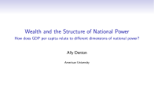

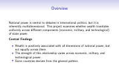

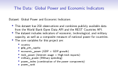

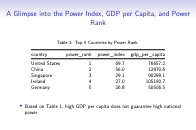

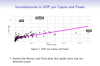

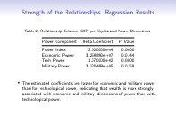

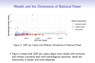

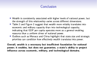

[interactive chart not shown]

Wealth and the Structure of National PowerHow does GDP per capita relate to different dimensions of national power?Ally DentonAmerican University

[interactive chart not shown]

OverviewNational power is central to debates in international politics, but it isinherently multidimensional. This project examines whether wealth translatesuniformly across different components (economic, military, and technological)of state power.Central Findings•Wealth is positively associated with all dimensions of national power, butnot equally across them.•The strength of this relationship varies across economic, military, andtechnological power.•Some countries deviate from the general pattern.

[interactive chart not shown]

The Data: Global Power and Economic IndicatorsDataset: Global Power and Economic Indicators•This dataset has 250 observations and combines publicly available datafrom the World Bank Open Data API and the REST Countries API.•The dataset includes indicators of economic, technological, and militarycapacity, as well as a composite measure of national power for countries.•The core variables for this project are:•country•gdp_per_capita•economic_power (GDP × GDP growth)•tech_power (Internet usage × High-tech exports)•military_power (Military spending)•power_index (combination of the power components)•power_rank

[interactive chart not shown]

A Glimpse into the Power Index, GDP per Capita, and PowerRankTable 1: Top 5 Countries by Power Rankcountrypower_rank power_index gdp_per_capitaUnited States169.776657.2China256.012970.6Singapore329.190299.1Ireland427.0105190.7Germany526.850506.5•Based on Table 1, high GDP per capita does not guarantee high nationalpower.

[interactive chart not shown]

Inconsistencies in GDP per Capita and PowerUnited StatesChinaMonaco0204060050000100000150000200000GDP per CapitaPower IndexFigure 1: GDP per Capita and Power•Outliers like Monaco and China show that wealth alone may notdetermine power.

[interactive chart not shown]

[interactive chart not shown]

Wealth and the Dimensions of National Power051015050000100000150000200000GDP per CapitaStandardized Index ValuesPower Componenteconomic_powermilitary_powertech_powerFigure 2: GDP per Capita and Different Dimensions of National Power•Figure 2 shows that GDP per capita aligns more closely with economicand military outcomes than with technological outcomes, where therelationship is weaker and more dispersed.

[interactive chart not shown]